# Printable Timetables

Aaron Priven, October 2013 (modified August 2022)

# About printable timetables

Printable timetables are the PDF files placed on the AC Transit web site with the complete timetable information in them. They are designed to be printed on standard letter-size paper.

Public timetables are put together by an Applescript program called “make-timetable”. This program starts with a blank InDesign document, chooses the correct master page from that document, adds the appropriate cover, schedules, and map, and saves the completed timetable. The program isn’t completely perfect, so the user does have to examine the finished result before exporting the InDesign document to PDF and then uploading it to the web site.

# Configuring timetables

Timetables are configured using a few fields[^1] in the Actium FileMaker database.

## PubTimetables table

Every public timetable has a record in the PubTimetables table.

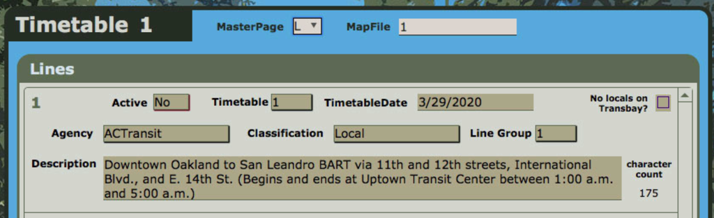

The following fields are used:

### ID

This is next to “Timetable”, and is the ID of the public timetable. It should be the same as the letter or number of the first line of the timetable.

### MasterPage

This is the master page that should be used for the document. At the moment, there are four master pages: L (local), T (transbay), E (early bird), and S (supplemental).

### MapFIle

This is the name (without extension) of the map file to be added to the timetable. The script looks for a file with this name, and the .pdf extension, in the “PubInfSys – Documents/Actium/Maps/Repository/_linesnames” folder.

Each map should be one of three sizes: 6.66” wide by 7.5” high (only if it fits well), 10” wide by 7.5” high, or 7.5” wide by 10” high. Maps, when recreated, should not have a box drawn around them: it is not helpful for printing and makes them look worse when used online.

### Lines portal

The box marked “Lines” shows the relevant entries in the Lines table for this timetable. Fields can be edited here or in the separate Lines entry screen.

## Lines table

The Lines table has several fields used for public timetables (as well as fields used for other things). Each Lines record contains data relating to one particular bus line.

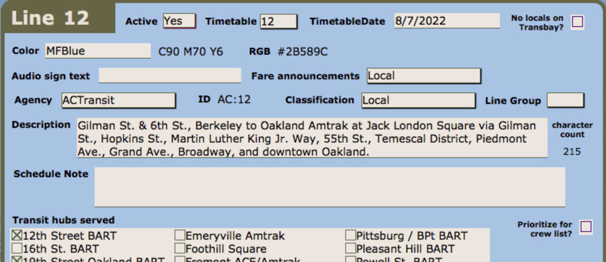

### PubTimetable

The PubTimetable field in the Lines record is a cross-reference to the appropriate record in the PubTimetables table. The drop-down menu displays only the IDs that exist in PubTimetables, so those entries should be created first.

I’ve tried to combine relatively few lines into a single timetable, because the maps are already pretty complicated and they get worse when multiple lines are placed on the same one. But the system can handle it.

### TimetableDate

The TimetableDate field is used to determine what date is put on the cover of the timetable (“Effective: July 12, 2020,” or whatever). Each line has its own date, and the actual timetable uses whichever one is later. This is so we can use the same date in other places later, where only one of those lines is present. (This field probably should have been called “EffectiveDate”.)

### NoLocalsOnTransbay

This field tells the system whether local passengers are allowed on this line. This affects the cover.

# Generating the timetable text

The timetable text is generated using the “actium.pl timetables” program.

From a shell prompt, type

actium.pl timetables -s *signup*

“Signup” should be the appropriate signup folder under PubInfSys – Documents/Actium/signups , so if the current folder is PubInfSys – Documents/Actium/signups /w22, you would enter

actium.pl timetables -s w22

This will generate a set of text files: all.txt in the diretctory w22/timetables, which is used for the timetable text used for signage, and a series of files, one for each timetable, in the directory w22/timetables/pub-idtags . These are the text files that will be placed into the linked text boxes by the “make_timetable” script.

The program generates almost all the information on the timetable, including much of what’s on the cover. The program automatically determines the size and placement of the line numbers on the cover, creates the effective date, and adds notes for the bottom of the cover for the days of service and (for Transbay lines) whether local passengers are allowed. It also contains the actual tables of times.

# Editing and exporting the cover line description

The cover page is mostly generated from the database, but the description of what each line serves on the cover is stored as artwork, in a separate InDesign file. The InDesign file is in “PubInfSys – Documents/PubTimetables” The file itself is called “CoverPages.indd”.

Each page of CoverPages.indd represents the cover of one timetable. Each page has a gradient bar and white line designation, both of which are non-printing and will not be visible when exported. The gradient is there only to show the position of the bar and title elements on the main covers. The white line designation shows on which timetable this cover should be placed. For timetables with more than one line, all lines should be put in the white text, separated by either underlines or spaces (but not both).

An Applescript called “export_coverpages.scpt” is used to export the cover pages to separate PDF files, to be placed in the final timetable document. The cover page PDFs are stored in the “PubInfSys – Documents/Actium/tableart/CoverPages folder. Open the file “PubInfSys – Documents/Actium/Applications/export_coverpages.scpt” in Script Editor, and run the script by clicking “run” at the top.

# Writing the cover line description

The cover line description needs to be written manually, and should ideally be done in concert with the Planning and Scheduling departments. Most cover descriptions are pretty simple: they list the cities or major neighborhoods the line runs through, with a list of streets or other significant places the line serves underneath each city..

A number of paragraph styles have been created to help format these descriptions easily.

## Key styles

### CoverCity and CoverCitySm

The CoverCity style is used to highlight cities, major neighborhoods (of Oakland or Fremont, such as Montclair or Irvington), and for 600-series lines, schools that the line serves. It automatically puts a triangle bullet next to the text. CoverCitySm is not intended for subheads; it is supposed to be used in place of CoverCity when the text is very long and space is very limited.

### CoverPlace

CoverPlace is the main style used for streets or other areas served by that bus line. Generally, we spell out the street types (“Street”, “Avenue”, etc.) There is also CoverPlaceSm for timetables with very limited space.

### CoverNote and CoverNoteBold

These are not normally used in the cover description but can be used there if it seems appropriate in a particular circumstance.

## Multiple line styles

Most timetables use only those two styles. Timetables with multiple lines often use other styles.

### CoverLineInDesc

This style is used to put the white route designation to the left of the description itself, in the color bar. It is designed to take up no vertical space, so the next line actually appears next to, rather than under, the line identified with this style.

The idea is that any initial description applies to every line in the timetable, while description text that only applies to one of the lines in the timetable would be placed alongside the cover line. The NX4/NXC gives an example of mixed usage.

Because of the weird way this style plays with vertical space, the text frame of a cover description that starts with this style may need to be moved.

### CoverLocalPax

Transbay timetables either say “Local Passengers Permitted for Local Fare” or “No Local Passengers Allowed.” Usually, this is added automatically by the program, but for a multi-line timetable where the different lines have different rules, this has to be added in the description.

# Making the timetables

Once the timetable program is run and the covers are exported, the timetable documents themselves can be created. The program that does this is another Applescript program called “make_timetable.scpt”. This is in the folder PubInfSys – Documents/Actium/Applications

Before this program is run the first time for any signup, a second file in that folder called “current_signup.scpt” needs to be edited. It has just three lines:

> **on** current_signup()

> **return** "f22" -- replace this with "w17" or "sp18" or whatever

> **end** current_signup

Change “f22” to whatever the current signup is (for example “w22”), and then save and close this file.

Once this is done, open “make_timetable.scpt” with Script Editor, and and click “run” to run the program.

The script will show you a list of timetables you can make. You can select just one, or the whole batch, or anywhere in between. (If you made changes to earlier versions of a timetable and don’t want those changes lost, make sure you don’t select them in this list.) Then click “OK.” The program will run for a while. This takes some time to do for a large number of timetables.

The result files will be stored in the signup folder under timetables/tableart. Normally I look at them there and then move them to PubInfSys – Documents/Actium/tableart/indd once I’m satisfied that they’re correct.

Because it’s useful to have old versions, the file names of the InDesign files each have the effective date listed.

# Structure of timetables

Each timetable is based on the master document “TimetableMasters.indd”, which is stored in PubInfSys – Documents/PubTimetables

Originally, the timetables were set up on a standard letter-size page (8½ʺ by 11ʺ), with a half-inch margin around all sides. Unfortunately, due to the way some PDF viewers shrink pages when printing, this ended up being printed with an margin larger than originally intended -- the PDF viewer would shrink the entire page, including margin, to fit within the printer’s printable area, yielding a double margin.

Now, the pages have been reset on a 10¼ʺ by 7¾ʺ page, with only a ⅛ʺ margin designed in the page. This results in a better approximation of the correct size when printed with the “shrink to fit” option checked. However, the best way to print them is actually to center the image in the page and leave the “shrink to fit” option unchecked. This yields a print with the fold lines in the right place.

## Master pages

There are a series of master pages that define each type of timetable. These master pages are similar to the master pages found in the pole schedule documents: they contain objects common to every timetable as well as a series of linked text boxes designed to be overridden and filled with placed text from a computer-generated text file.

The master pages are “T”, for Transbay timetables, “E” for Early Bird timetables, “S”, for supplementary timetables, and “L”, for local timetables. The only difference is in the cover: the color, whether the Transbay icon is present, and whether it says “Supplementary Service.” The timetables are designed to be very similar to the print shop’s timetable design.

Two additional master pages are present, both with empty text frames. “B-Blank” is landscape, and “R-Rotate” is portrait. These are used in appropriate timetables.

## Layers

Each spread of master pages has a series of objects, on several different layers. The “Background” layer has the items that are common to every timetable of that type (gradient, “AC Transit Schedule”, etc.). The “Map” layer contains the map. The “Timetable Text” layer has a series of linked text frames that are designed to accept a placed text file, output by the “actium.pl timetables” program. The “Cover Text” layer is where the cover text page should be placed. The “Preview” layer should normally be hidden; it has artwork on it that is intended to be used in the interim “preview” period between when the schedules are published and when they go into effect.

# Manual fixes

Most of the timetables should be OK as they are, straight out of the program, once the cover texts are all written. Unfortunately there will be exceptions. Until the maps are all recreated at the proper size, they will need to be resized manually. There will also be rare occasions where the program underestimates the amount of space required for a particular timetable, often because the colored header at the top of the table is too long. In this case, the text must be adjusted to allow the whole timetable to fit. In some cases, the script may add an extra page, which must be removed.

# Exporting and Uploading

There’s a script called “export_timetables.scpt” in the PubInfSys – Documents/Actium/Applications folder. This script will ask you to choose timetable files to export, and then export all the timetables as separate PDFs. First it saves one with all line names and effective date (e.g., “1_1R-2012_12_16.pdf”) to PubInfSys/ACTium/tableart/pdf/dates , and then copies that file, once per each included line, to Actium/tableart/pdf/lines (e.g., “1-timetable.pdf” and “1R-timetable.pdf”) , and then again, to Actium/tableart/pdf/oneline-dates/, which is the version used for the new Drupal web site. Timetables with multiple lines must be uploaded multiple times, once for each line (so there are three identical copies of the 72/72M/802 timetable).

[^1]: Explanation of tables, fields, and records from the FileMaker Pro tutorial: “A database file is organized into one or more *tables*. Tables store *records*. Each record is a collection of *fields*. Imagine your address book is a FileMaker Pro database file. Each listing in your address book is one record in an Address Book table. Each record has information, such as name, address, city, and so on. Each of these pieces of information—name, address, and city—is stored in a separate field.”